# ADA_P6

Zane Hassoun

3/8/2022

```r
colnames(df)
```

```
##  [1] "XPos"       "YPos"       "Year"       "Month"      "Day"
##  [6] "Depth"      "TransectID" "Area"       "Nhat"       "YearMonth"
## [11] "Impact"
```

## Fitting Two Dimensional Smoothers

1. Produce pre/post-impact spatial plots (using fields::quilt.plot(.)) of the observed data.

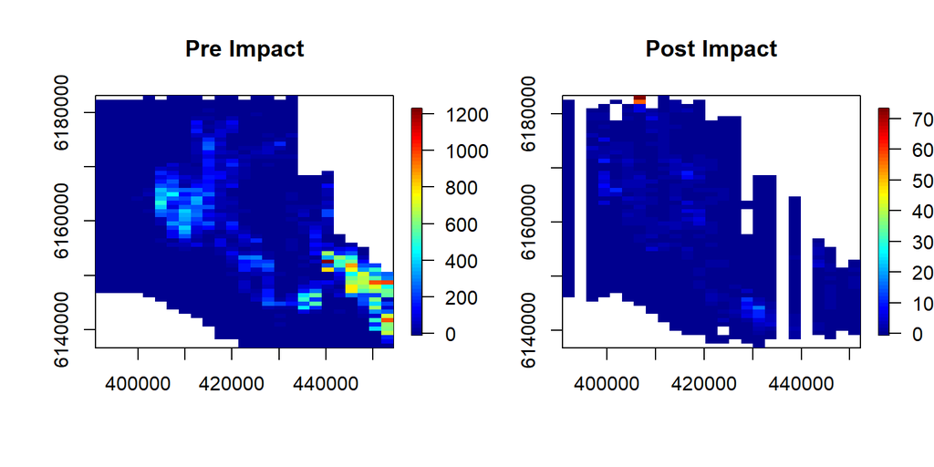

```r
#Fitting the Quilt Plots

par(mfrow=c(1,2))

# Loop across all phases


for(phase in c(0,1)){
  fields::quilt.plot(df$XPos[which(df$Impact == phase)],
                       df$YPos[which(df$Impact == phase)],
                       df$Nhat[which(df$Impact == phase)],
                       nrow=25, ncol=60,
                       #zlim=range(NhatPredLink$fit),
                       main=paste(ifelse(phase == 0, "Pre Impact", "Post Impact")))
}
```

2. Fit a quasi-Poisson penalised spline based GAM (mgcv::gam(.); use the default options) with a two dimensional smoother for the spatial coordinates and a one dimensional smoother for Depth, whilst including Impact (not as an interaction term for now). Print out a summary of the resultant model, which will be referred to as PRS_2D.

```r
#Fitting a Quasi-Poisson with 2D Smoother for X and Y and 1D for depth and nothing for impact

PRS_2D = mgcv::gam(Nhat ~ s(XPos, YPos) + s(Depth) + Impact,
                   family = quasipoisson,
                   offset = log(Area),
                   data = df)
summary(PRS_2D)
```

```
##
## Family: quasipoisson
## Link function: log
##
## Formula:
## Nhat ~ s(XPos, YPos) + s(Depth) + Impact
##
## Parametric coefficients:
##             Estimate Std. Error t value Pr(>|t|)
## (Intercept) -0.44109    0.13661  -3.229  0.00124 **
## Impact1      0.23830    0.01182  20.162  < 2e-16 ***
## ---
## Signif. codes:  0 '***' 0.001 '**' 0.01 '*' 0.05 '.' 0.1 ' ' 1
##
## Approximate significance of smooth terms:
##                 edf Ref.df     F p-value
## s(XPos,YPos) 29.000 29.000 462.0  <2e-16 ***
## s(Depth)      7.308  7.706 131.1  <2e-16 ***
## ---
## Signif. codes:  0 '***' 0.001 '**' 0.01 '*' 0.05 '.' 0.1 ' ' 1
##
## R-sq.(adj) =  0.0596   Deviance explained = 25.5%
## GCV = 230.78  Scale est. = 55.167    n = 27854
```

3. View the partial plots for PRS_2D.

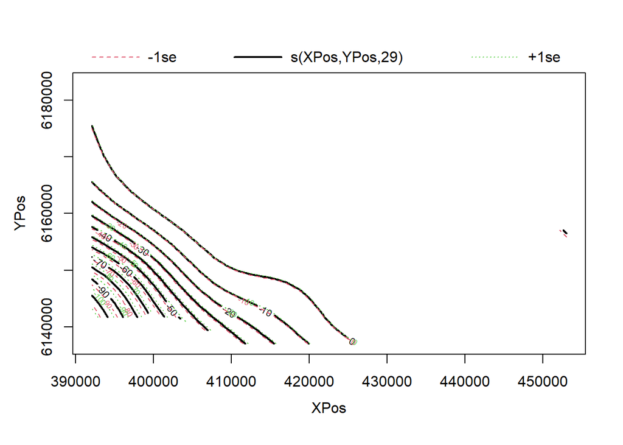

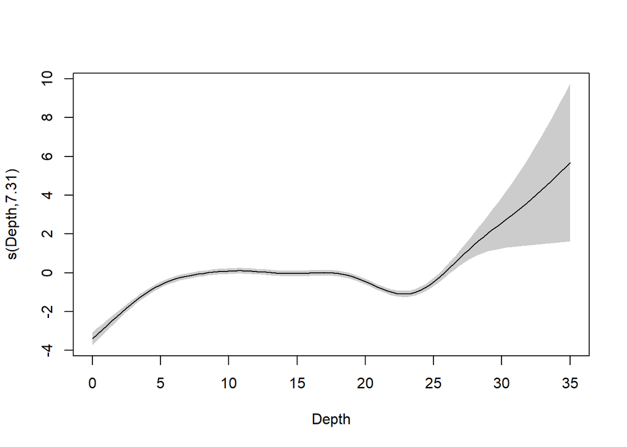

```r
#Viewing the Partial Plots

plot(PRS_2D, shade = T)
```

4. Use HornsRevPredictionData.csv to make pre/post-impact predictions on this fine grid using PRS_2D. Produce a spatial plot of the results (both on the link and response scale; set the same 𝑧-scale range (zlim) for pre and post-impact).

```r
pred_link = predict(PRS_2D,
                    newdata = pred_data,
                    type = 'link')
pred_probs = predict(PRS_2D,
                    newdata = pred_data,
                    type = 'probs')
```

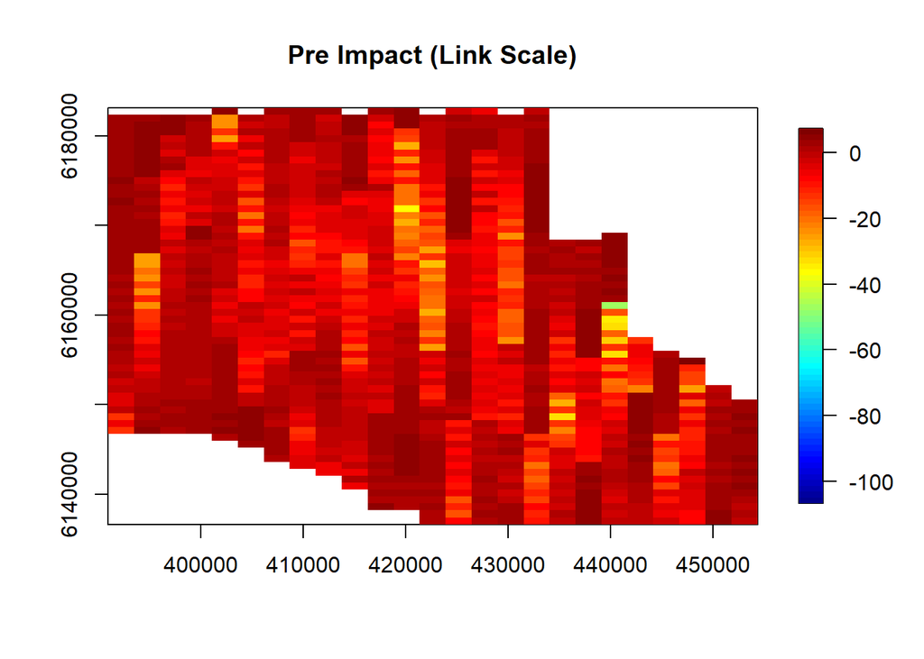

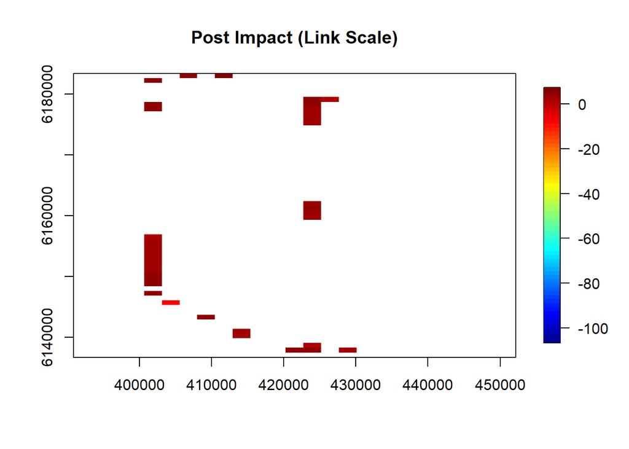

```r
plot.new()
# Loop across all phases



for(phase in c(0,1)){
  fields::quilt.plot(df$XPos[which(df$Impact == phase)],
                       df$YPos[which(df$Impact == phase)],
                       pred_link[which(df$Impact == phase)],
                       nrow=25, ncol=60,
                     zlim = range(pred_link),
                       main=paste(ifelse(phase == 0, "Pre Impact (Link Scale)", "Post Impact (Link Scale)")))
}
```

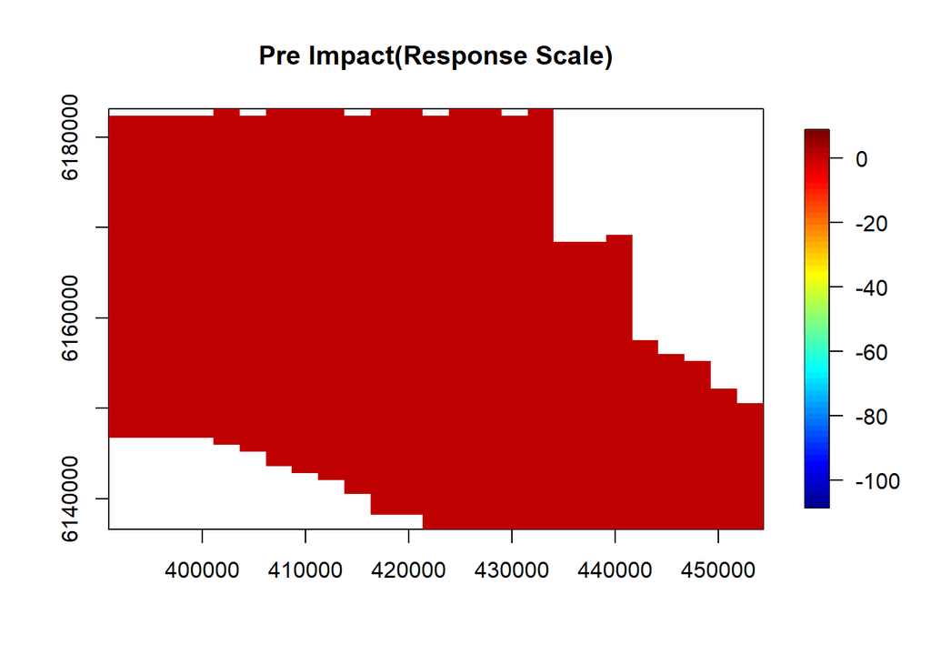

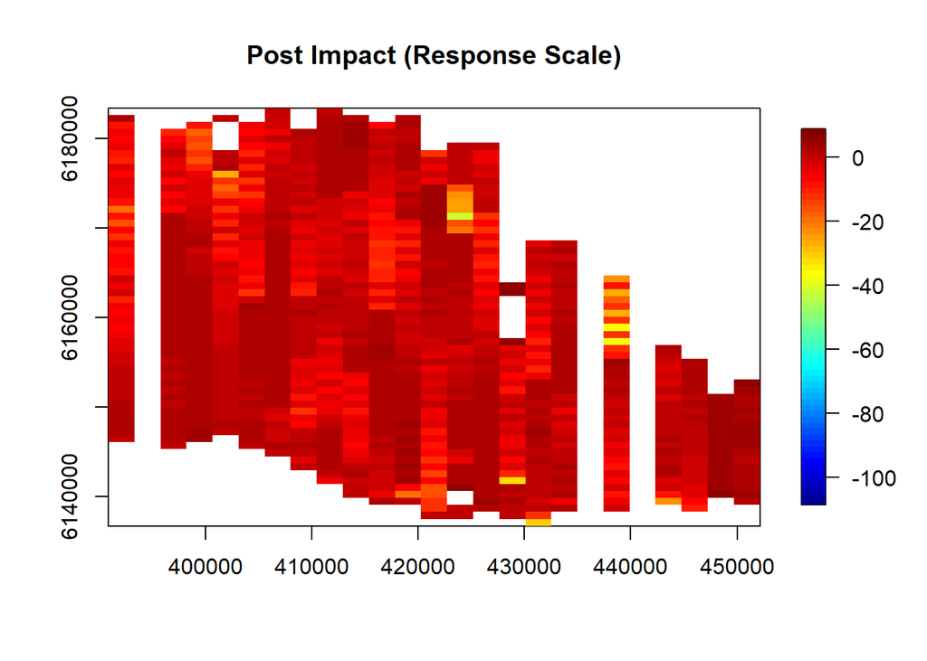

```r
for(phase in c(0,1)){
  iteration = df$Impact %in% phase
  fields::quilt.plot(df$XPos[which(df$Impact == phase)],
                       df$YPos[which(df$Impact == phase)],
                       pred_probs[which(df$Impact == phase)],
                       nrow=25, ncol=60,zlim = range(pred_probs),
                       main=paste(ifelse(phase == 0, "Pre Impact(Response Scale)", "Post Impact (Response Scale)")))
}
```

## Fitting two dimensional smoothers with an interaction term

5. Fit a similar model to PRS_2D, but now add Impact as an interaction term in the two dimensional spatial smoother (leave everything else the same). Print out a summary of the resultant model, which will be referred to as PRS_2DInt

```r
#Fitting a Quasi-Poisson with 2D Smoother for X and Y and 1D for depth and nothing for impact

PRS_2DInt = mgcv::gam(Nhat ~ s(XPos, YPos, by = Impact) + s(Depth) + Impact,
                   family = quasipoisson,
                   offset = log(Area),
                   data = df)
summary(PRS_2DInt)
```

```
##
## Family: quasipoisson
## Link function: log
##
## Formula:
## Nhat ~ s(XPos, YPos, by = Impact) + s(Depth) + Impact
##
## Parametric coefficients:
##             Estimate Std. Error t value Pr(>|t|)
## (Intercept)  -5.4093     0.3746  -14.44   <2e-16 ***
## Impact1       6.6118     0.3859   17.13   <2e-16 ***
## ---
## Signif. codes:  0 '***' 0.001 '**' 0.01 '*' 0.05 '.' 0.1 ' ' 1
##
## Approximate significance of smooth terms:
##                         edf Ref.df     F p-value
## s(XPos,YPos):Impact0 28.945 28.999 377.4  <2e-16 ***
## s(XPos,YPos):Impact1 28.878 28.990 373.2  <2e-16 ***
## s(Depth)              7.939  8.073 139.1  <2e-16 ***
## ---
## Signif. codes:  0 '***' 0.001 '**' 0.01 '*' 0.05 '.' 0.1 ' ' 1
##
## R-sq.(adj) =  0.118   Deviance explained =   36%
## GCV = 198.62  Scale est. = 60.11     n = 27854
```

6. View the partial plots for PRS_2DInt.

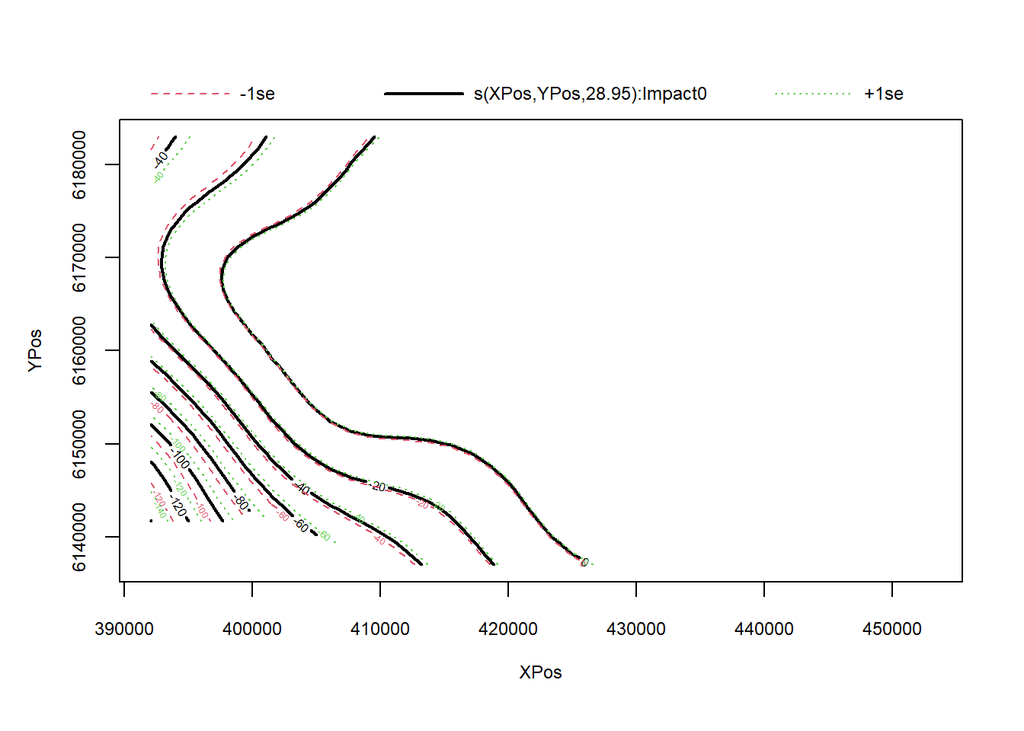

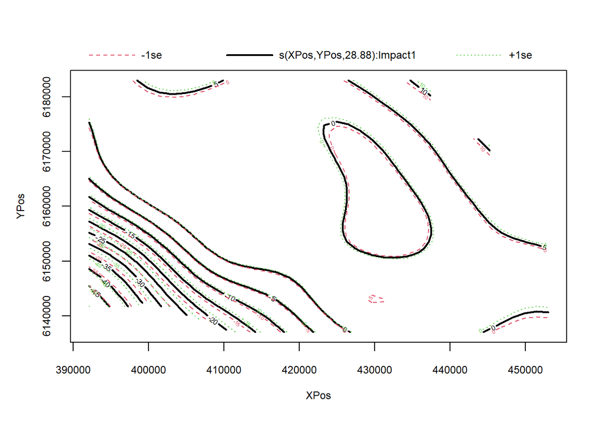

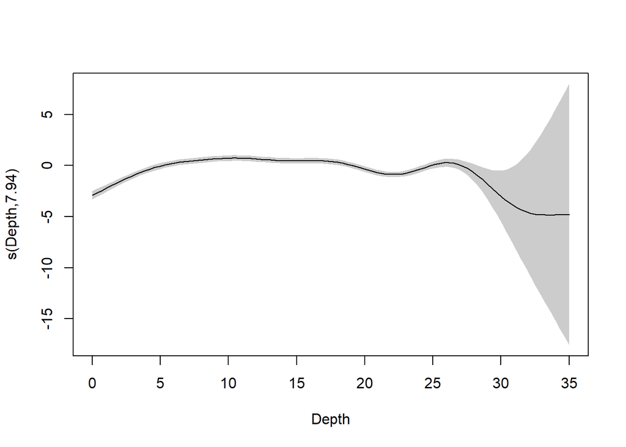

```r
#Viewing the Partial Plots

plot(PRS_2DInt, shade = T)
```

```r
pred_linkINT = predict(PRS_2DInt,
                    newdata = pred_data,
                    type = 'link')
pred_probsINT = predict(PRS_2DInt,
                    newdata = pred_data,
                    type = 'probs')
```

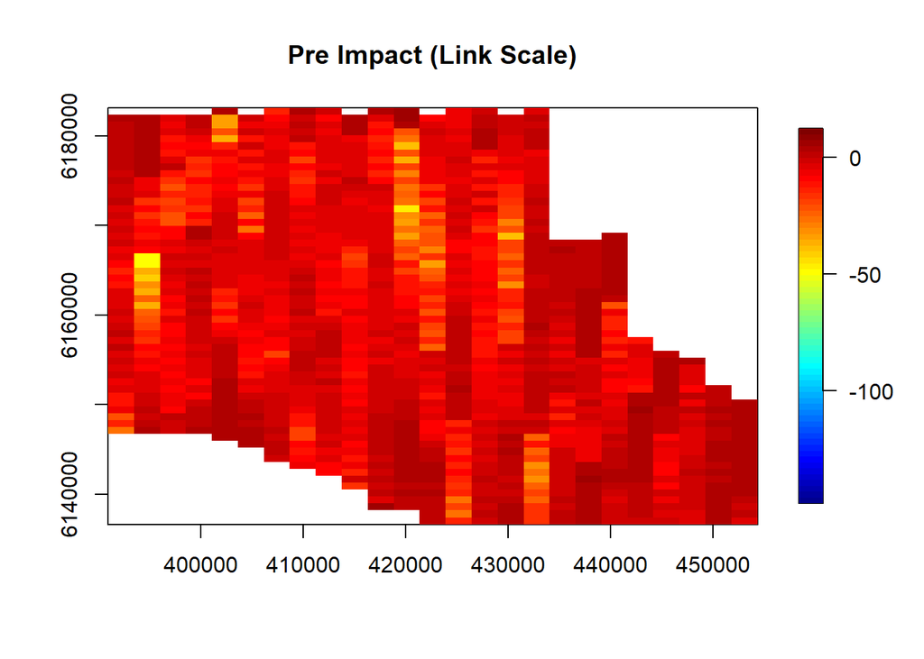

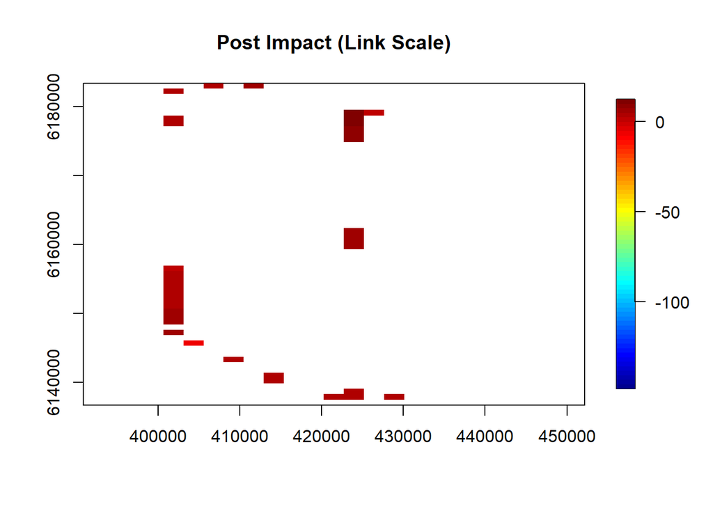

```r
plot.new()
# Loop across all phases



for(phase in c(0,1)){
  fields::quilt.plot(df$XPos[which(df$Impact == phase)],
                       df$YPos[which(df$Impact == phase)],
                       pred_linkINT[which(df$Impact == phase)],
                       nrow=25, ncol=60,
                     zlim = range(pred_linkINT),
                       main=paste(ifelse(phase == 0, "Pre Impact (Link Scale)", "Post Impact (Link Scale)")))
}
```

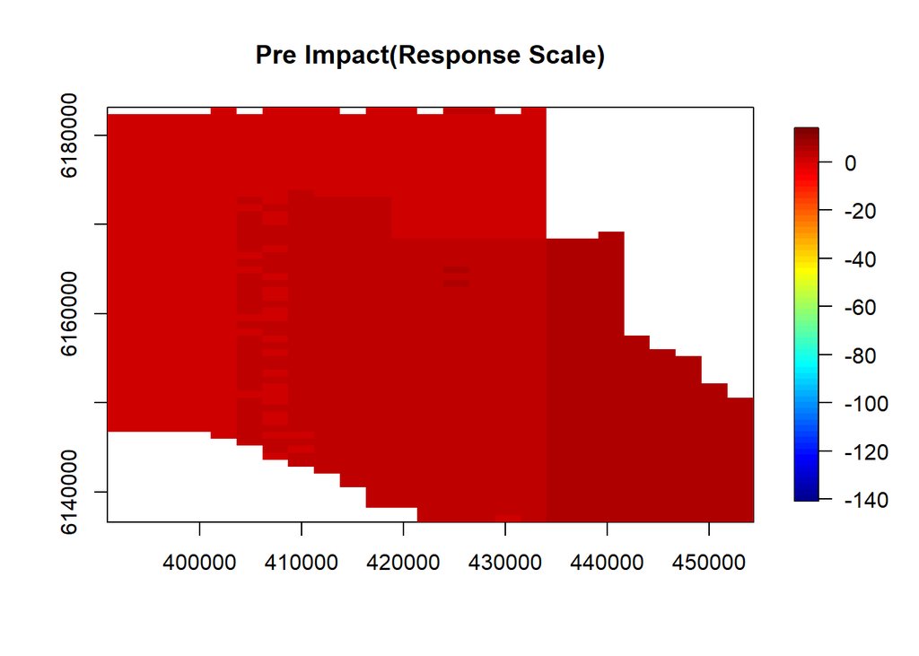

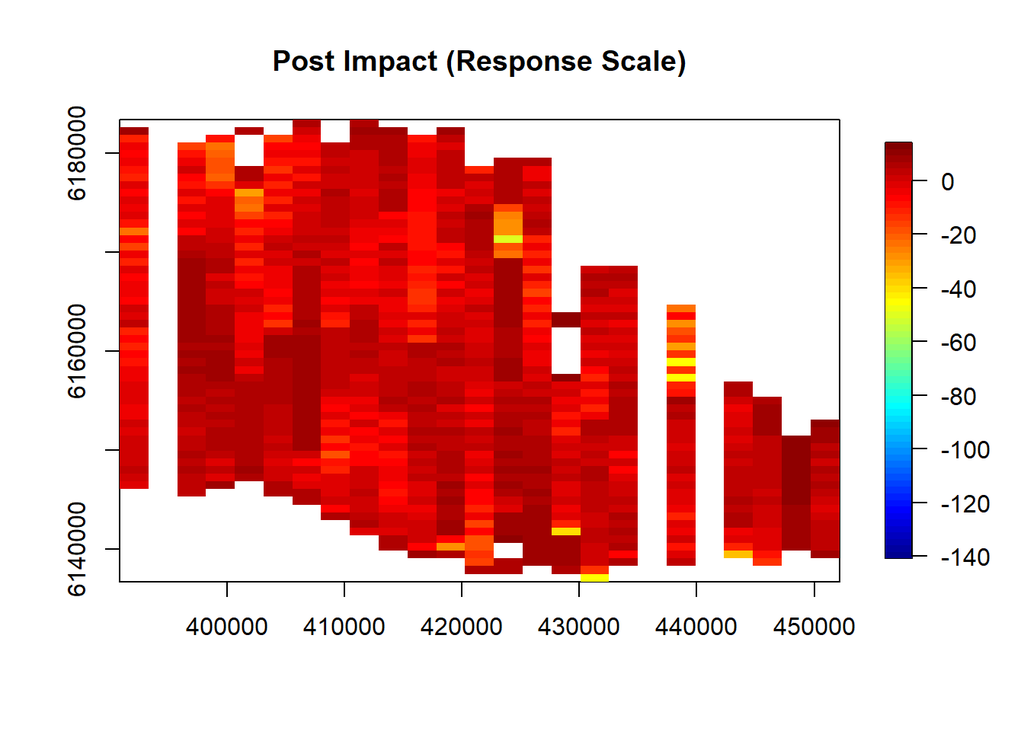

```r
for(phase in c(0,1)){
  iteration = df$Impact %in% phase
  fields::quilt.plot(df$XPos[which(df$Impact == phase)],
                       df$YPos[which(df$Impact == phase)],
                       pred_probsINT[which(df$Impact == phase)],
                       nrow=25, ncol=60,zlim = range(pred_probsINT),
                       main=paste(ifelse(phase == 0, "Pre Impact(Response Scale)", "Post Impact (Response Scale)")))
}
```

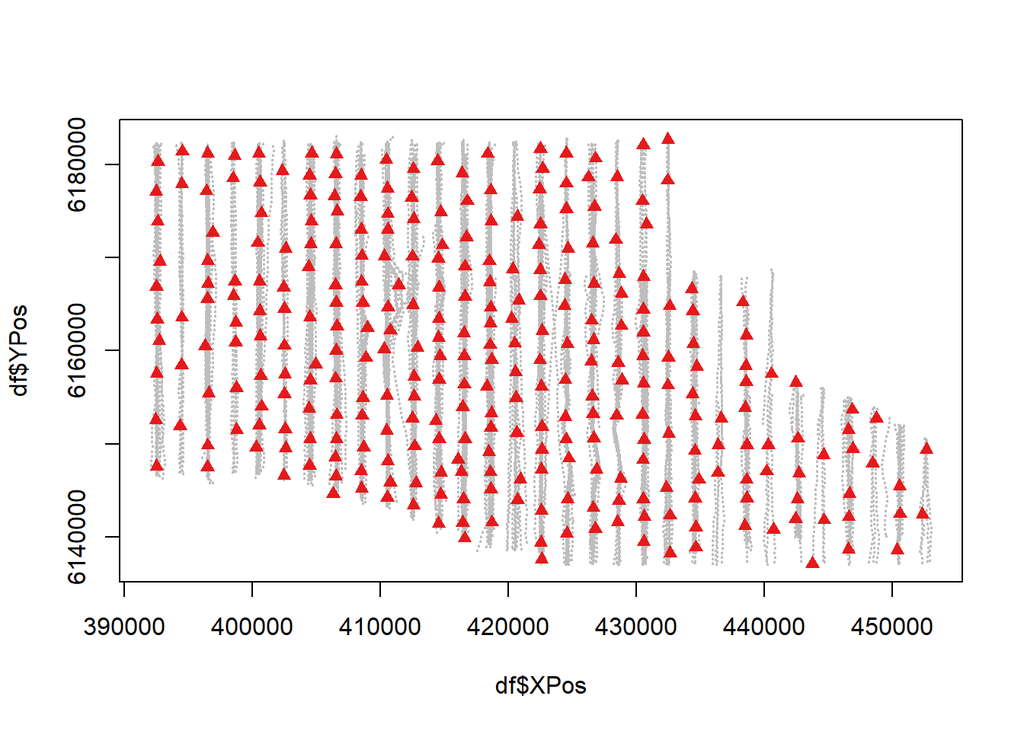

```r
library(MRSea)
knotGrid = MRSea::getKnotgrid(coordData = cbind(df$XPos,df$YPos),
                              numKnots = 300,
                              plot = FALSE)

plot(df$XPos, df$YPos, col="grey", pch=19, cex=0.2)
points(knotGrid[, 1], knotGrid[, 2], pch=17, col="#e41a1c")
```

```r
PRS_2DInt_knots15 = mgcv::gam(Nhat ~ s(XPos, YPos, by = Impact, k=15) + s(Depth) + Impact,
                   family = quasipoisson,
                   offset = log(Area),
                   data = df)
summary(PRS_2DInt_knots15)
```

```
##
## Family: quasipoisson
## Link function: log
##
## Formula:
## Nhat ~ s(XPos, YPos, by = Impact, k = 15) + s(Depth) + Impact
##
## Parametric coefficients:
##             Estimate Std. Error t value Pr(>|t|)
## (Intercept)  -0.9636     0.1816  -5.305 1.13e-07 ***
## Impact1       2.6179     0.1088  24.065  < 2e-16 ***
## ---
## Signif. codes:  0 '***' 0.001 '**' 0.01 '*' 0.05 '.' 0.1 ' ' 1
##
## Approximate significance of smooth terms:
##                         edf Ref.df     F p-value
## s(XPos,YPos):Impact0 13.990 14.000 821.6  <2e-16 ***
## s(XPos,YPos):Impact1 13.987 14.000 532.4  <2e-16 ***
## s(Depth)              8.063  8.214 244.3  <2e-16 ***
## ---
## Signif. codes:  0 '***' 0.001 '**' 0.01 '*' 0.05 '.' 0.1 ' ' 1
##
## R-sq.(adj) =  0.0808   Deviance explained = 31.1%
## GCV = 213.49  Scale est. = 59.986    n = 27854
```

```r
PRS_2DInt_knots40 = mgcv::gam(Nhat ~ s(XPos, YPos, by = Impact, k=40) + s(Depth) + Impact,
                   family = quasipoisson,
                   offset = log(Area),
                   data = df)
summary(PRS_2DInt_knots40)
```

```
##
## Family: quasipoisson
## Link function: log
##
## Formula:
## Nhat ~ s(XPos, YPos, by = Impact, k = 40) + s(Depth) + Impact
##
## Parametric coefficients:
##             Estimate Std. Error t value Pr(>|t|)
## (Intercept)  -3.0595     0.4661  -6.565 5.31e-11 ***
## Impact1       4.2562     0.4942   8.612  < 2e-16 ***
## ---
## Signif. codes:  0 '***' 0.001 '**' 0.01 '*' 0.05 '.' 0.1 ' ' 1
##
## Approximate significance of smooth terms:
##                         edf Ref.df     F p-value
## s(XPos,YPos):Impact0 38.577 38.957 297.0  <2e-16 ***
## s(XPos,YPos):Impact1 38.883 38.991 347.1  <2e-16 ***
## s(Depth)              6.919  7.406 112.2  <2e-16 ***
## ---
## Signif. codes:  0 '***' 0.001 '**' 0.01 '*' 0.05 '.' 0.1 ' ' 1
##
## R-sq.(adj) =  0.138   Deviance explained = 38.5%
## GCV = 191.26  Scale est. = 60.179    n = 27854
```

10. 1. for k = 15

```r
pred_link15 = predict(PRS_2DInt_knots15,
                    newdata = pred_data,
                    type = 'link')
pred_probs15 = predict(PRS_2DInt_knots15,
                    newdata = pred_data,
                    type = 'probs')
```

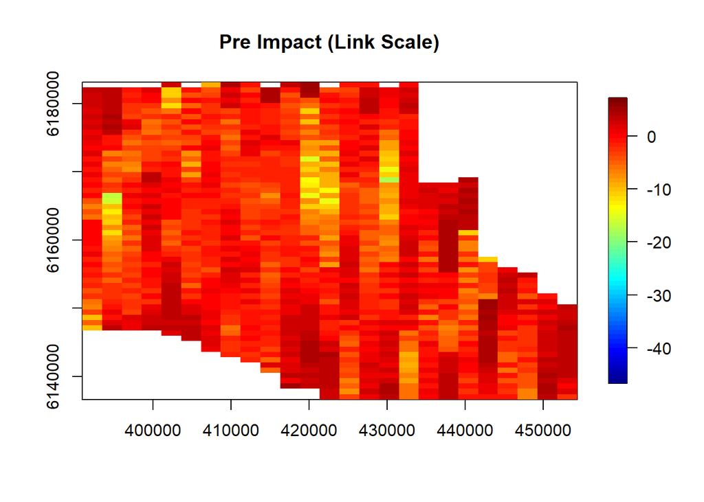

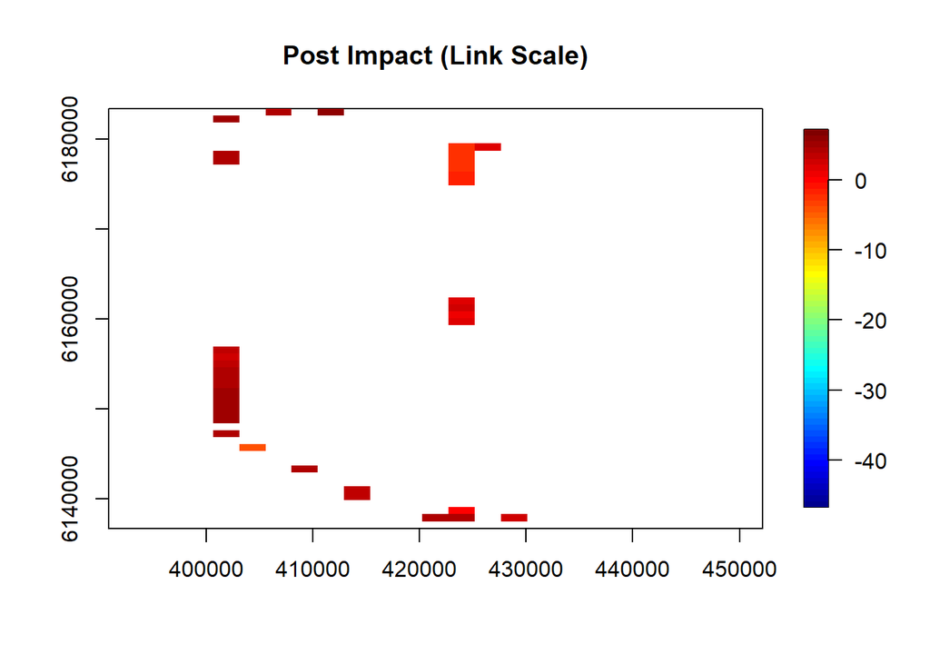

```r
plot.new()
# Loop across all phases



for(phase in c(0,1)){
  fields::quilt.plot(df$XPos[which(df$Impact == phase)],
                       df$YPos[which(df$Impact == phase)],
                       pred_link15[which(df$Impact == phase)],
                       nrow=25, ncol=60,
                     zlim = range(pred_link15),
                       main=paste(ifelse(phase == 0, "Pre Impact (Link Scale)", "Post Impact (Link Scale)")))
}
```

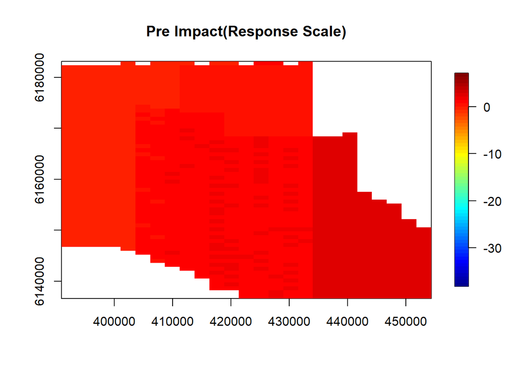

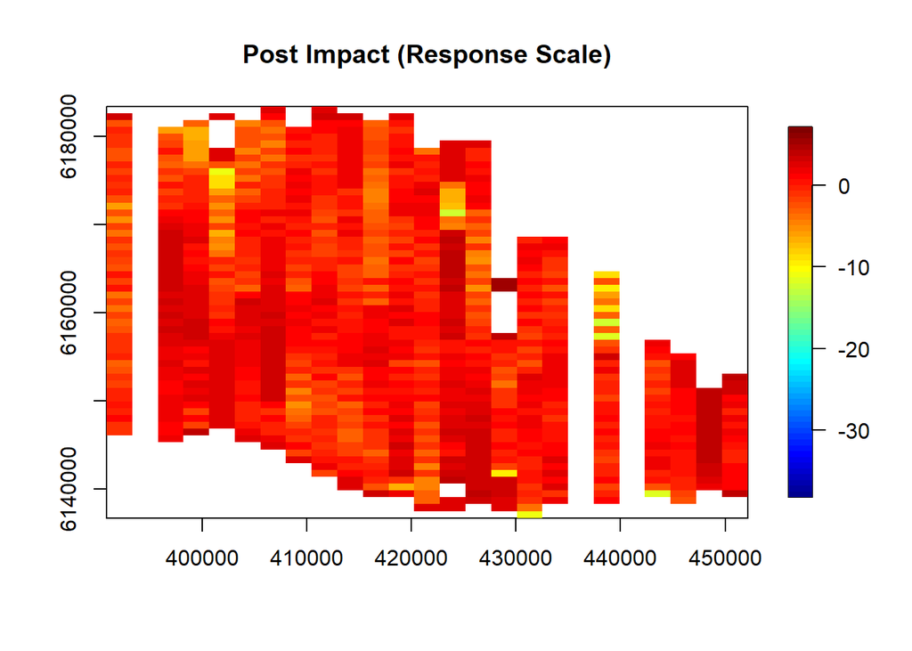

```r
for(phase in c(0,1)){
  iteration = df$Impact %in% phase
  fields::quilt.plot(df$XPos[which(df$Impact == phase)],
                       df$YPos[which(df$Impact == phase)],
                       pred_probs15[which(df$Impact == phase)],
                       nrow=25, ncol=60,zlim = range(pred_probs15),
                       main=paste(ifelse(phase == 0, "Pre Impact(Response Scale)", "Post Impact (Response Scale)")))
}
```

10. 2. for K = 40

```r
pred_link40 = predict(PRS_2DInt_knots40,
                    newdata = pred_data,
                    type = 'link')
pred_probs40 = predict(PRS_2DInt_knots40,
                    newdata = pred_data,
                    type = 'probs')
```

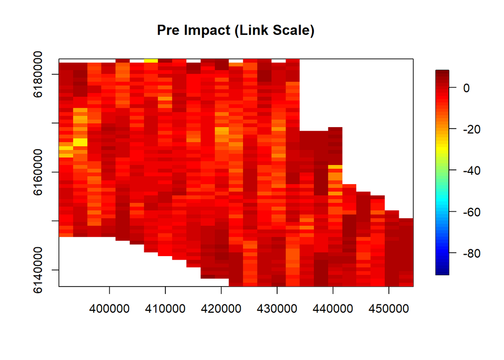

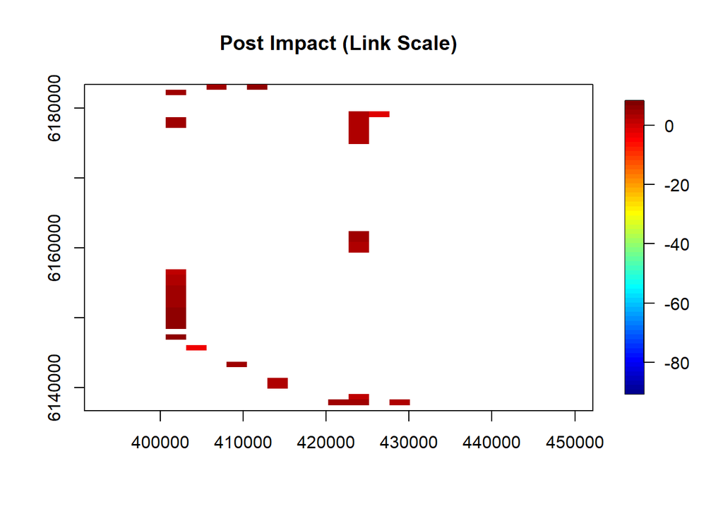

```r
plot.new()
# Loop across all phases



for(phase in c(0,1)){
  fields::quilt.plot(df$XPos[which(df$Impact == phase)],
                       df$YPos[which(df$Impact == phase)],
                       pred_link40[which(df$Impact == phase)],
                       nrow=25, ncol=60,
                     zlim = range(pred_link40),
                       main=paste(ifelse(phase == 0, "Pre Impact (Link Scale)", "Post Impact (Link Scale)")))
}
```

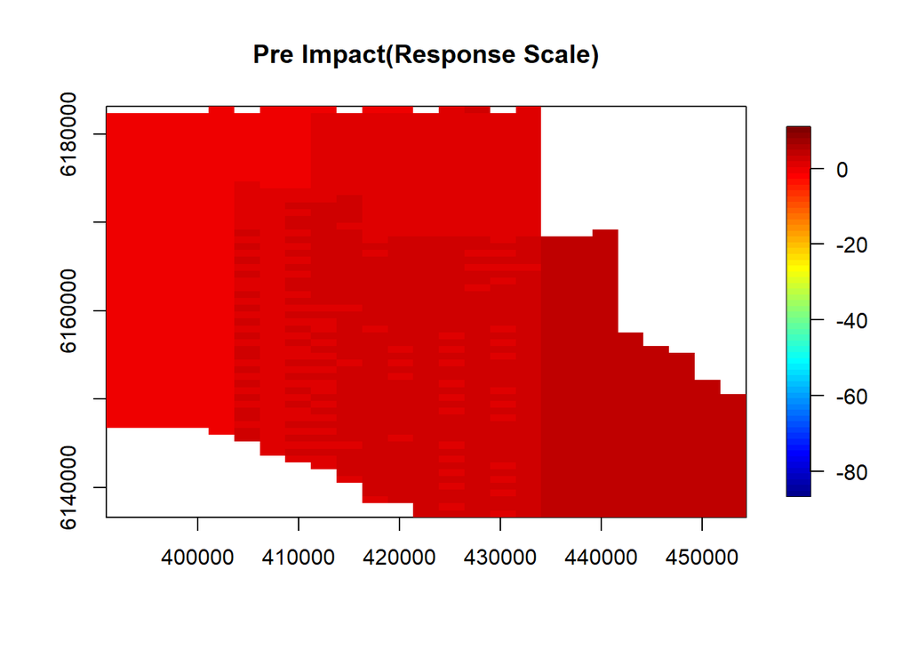

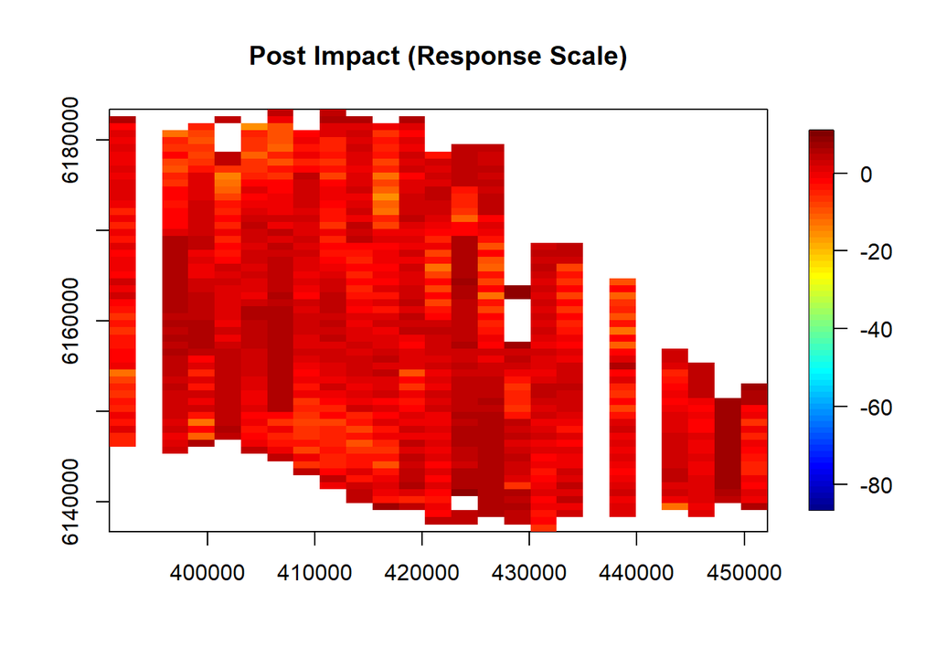

```r
for(phase in c(0,1)){
  iteration = df$Impact %in% phase
  fields::quilt.plot(df$XPos[which(df$Impact == phase)],
                       df$YPos[which(df$Impact == phase)],
                       pred_probs40[which(df$Impact == phase)],
                       nrow=25, ncol=60,zlim = range(pred_probs40),
                       main=paste(ifelse(phase == 0, "Pre Impact(Response Scale)", "Post Impact (Response Scale)")))
}
```